# Projet certification RNCP

# Contexte

#thème imposé : transition écologique

#contrainte donnée : 30000 lignes minimum

#collect des données : https://www.statistiques.developpement-durable.gouv.fr/

#sous-thème choisi : consommation d'électricité et de gas entre 2008 - 2019

#format des fichiers exploités : CSV

#concerne : les consommations et points de livraison des bâtiments professionnels par grand secteur d’activité et de ceux du secteur résidentiel d’au moins 10 logements.

# #Présentation des données

Le jeu de données concerne les consommations annuelles, de 2008 à 2019

Les points de livraison sont répartis en 4 catégories de consommation:

- les points de livraison d’une puissance inférieure ou égale à 36 kVA auxquels ne sont associés ni de code NAF ni de SIRET et pour lesquels les clients ne se sont pas déclarés auprès du fournisseur comme « professionnels » ou « éclairage public et assimilés » relèvent du secteur résidentiel ou de la catégorie des petits professionnels ;

- les points de livraison d’une puissance supérieure à 36 kVA relèvent de la catégorie des entreprises.

- Une quatrième catégorie correspond aux points de livraison non résidentiels pour lesquels il n’a pas été possible de dissocier les consommations des entreprises et des petits professionnels pour les données 2018 et 2019. (dispositif dérogatoire pour 2018 et 2019, qui concerne tous les gestionnaires de réseau de distribution de l’électricité hormis Enedis (en 2018 et 2019) et EdF-SEI (en 2019).

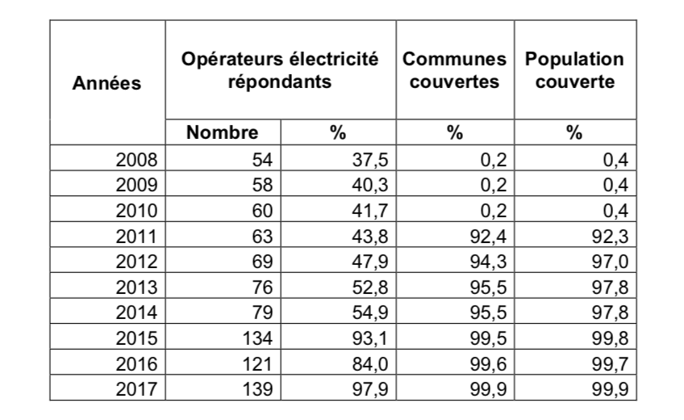

```python
from IPython.display import Image

Image("./répondants.png")
```

# #Import des librairies suivantes :

```python
#utilisation des librairies suivantes :
import pandas as pd
from sqlalchemy import create_engine
import psycopg2
from psycopg2 import OperationalError
import seaborn as sns

import matplotlib.pyplot as plt
import numpy as np

%matplotlib inline
```

# #Connexion

- en local
- sur Heroku

```python
#connection // local
def connection():
    db ="postgresql://sandrinevuachet:postgres@localhost:5432/eco"
    engine = create_engine(db, client_encoding='utf8')
    return engine

engine = connection()
```

```python
#connection // Heroku
#def connection():
    #db ="postgresql://bwrohjwhdhrmwi:7329cb14386e5a1496ce48df179b55186810b88e7d2d3156d97d64a01a83297d@ec2-54-220-229-215.eu-west-1.compute.amazonaws.com:5432/d3pvs2os3gslub"
    #engine = create_engine(db, client_encoding='utf8')
    #return engine

#engine = connection()
```

```python
#Host
#ec2-54-220-229-215.eu-west-1.compute.amazonaws.com
#Database
#d3pvs2os3gslub
#User
#bwrohjwhdhrmwi
#Port
#5432
#Password
#7329cb14386e5a1496ce48df179b55186810b88e7d2d3156d97d64a01a83297d
```

# Schéma relationnel

[figure not shown]

```python
from IPython.display import Image

Image("./schemautd.png")
```

# #Table principale (deliveries)

```python
all_data = pd.read_sql("""select * FROM deliveries where date in (2017,2018,2019);""",engine)
all_data.tail(5)
```

[output not shown]

```python
all_data.info()
```

```
<class 'pandas.core.frame.DataFrame'>
RangeIndex: 2177427 entries, 0 to 2177426
Data columns (total 9 columns):
 #   Column        Dtype
---  ------        -----
 0   id            int64
 1   energy_id     int64
 2   operator_id   int64
 3   date          int64
 4   territory_id  int64
 5   sector_id     int64
 6   conso         int64
 7   address       object
 8   city_id       int64
dtypes: int64(8), object(1)
memory usage: 149.5+ MB
```

# # Indicateurs

1 - Top 5 fournisseurs

2 - Top 5 des villes / consommation

4 - Top 3 des secteurs d'activité

5 - Evolution 2008-2019 / par secteur d'activité

# # GAZ

# 1. Top 5 fournisseurs

```python
#data cleaning
#with engine.connect() as connection:
    #grt = connection.execute("""UPDATE operators
    #SET operator = REPLACE(operator,'GRT_GAZ', 'GRT Gaz');""")
    #grt

#data cleaning
#with engine.connect() as connection:
    #result = connection.execute("""UPDATE operators
    #SET operator = REPLACE(operator,'GrDF', 'GRDF');""")
    #result
```

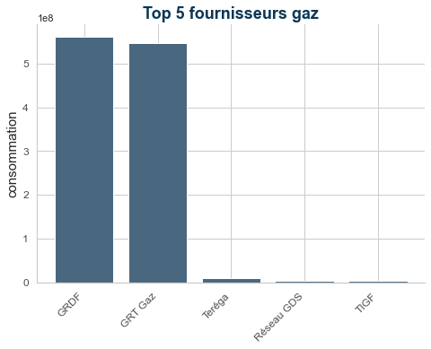

```
 GRDF : 561404773 MWh
 GRT Gaz : 546461643 MWh
 Teréga : 10457048 MWh
 Réseau GDS : 4956630 MWh
 TIGF : 4794852 MWh
```

```python
plt.show()
print("",fetchall[0][0],":",fetchall[0][1],"MWh\n",
     fetchall[1][0],":",fetchall[1][1],"MWh\n",fetchall[2][0],":",fetchall[2][1],"MWh\n",fetchall[3][0],":",fetchall[3][1],"MWh\n",fetchall[4][0],":",fetchall[4][1],"MWh\n")
```

# 2. Top 5 des villes qui consomment le plus de gaz

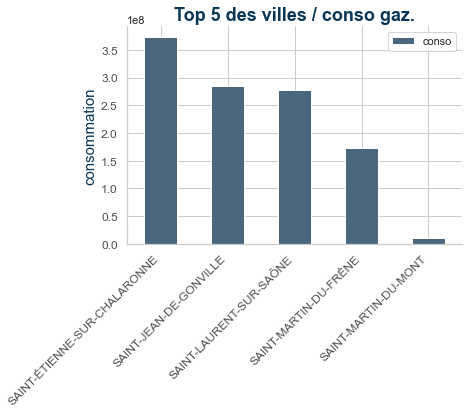

```
SAINT-ÉTIENNE-SUR-CHALARONNE : 373679477 MWh
SAINT-JEAN-DE-GONVILLE : 284290431 MWh
SAINT-LAURENT-SUR-SAÔNE : 277114342 MWh
SAINT-MARTIN-DU-FRÊNE : 172782166 MWh
SAINT-MARTIN-DU-MONT : 10457048 MWh
```

```python
for x in city_conso_gas.index:
    print(city_conso_gas['city'][x],":", city_conso_gas['conso'][x],'MWh')
```